# Establishing Ground Truth Labels

Assessing the performance of a machine learning pipeline in the clinical laboratory requires that we compare its predictions to some form of *ground truth* label. Given its importance, it is crucial that we perform a comprehensive evaluation of the options for defining ground truth. In clinical applications, predictions often must be made at time points with incomplete information. However, our ground truth label can often benefit from its retrospective or asynchronous nature by incorporating valuable information that is not available to models in real-time. Below, we explore the differences between various options for ground truth labels in our IV fluid contamination example.

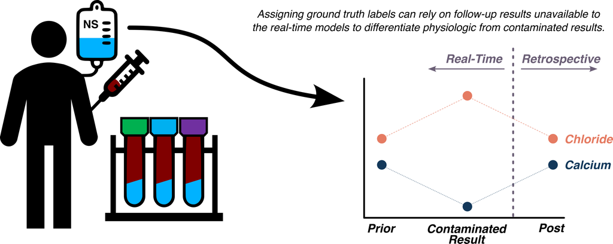

| Ground Truth | Example |
| --- | --- |
| Current State | Technologist-applied interpretive comments |
| Real-Time Deltas | Multivariate delta checks from mixing experiments<sup>1</sup> |
| Pre-Post Deltas | Data-derived thresholds for anomaly-resolution<sup>2</sup> |
| Retrospective ML | ML models that use the subsequent draw as features |
| Expert Review | Subject matter experts adjudicate each result |

The code chunk below demonstrates how we can define each of these options for ground truth labeling of our validation set in R, so that we can assess their similarities and differences. Comparing each option can be achieved on the aggregate using a Venn diagram, but for a more granular exploration of the data, we can use a tile plot instead, shown below.

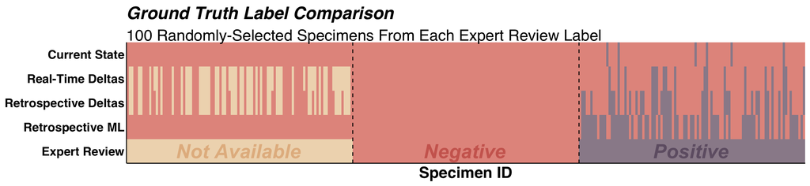

```r
suppressPackageStartupMessages(library(tidyverse))
suppressPackageStartupMessages(library(tidymodels))
options(timeout = 300)

## Load models
#model_realtime <- read_rds("https://api.figshare.com/v2/file/download/45631488") |> pluck("model") |> bundle::unbundle()
model_retrospective <- read_rds("https://api.figshare.com/v2/file/download/45631491") |> pluck("model") |> bundle::unbundle()
model_retrospective$fit$fit$ordered <- FALSE
predictors <- model_retrospective |> extract_recipe() |> pluck("term_info") |> dplyr::filter(role == "predictor") |> pluck("variable")

## Load validation data
validation <- arrow::read_feather("https://api.figshare.com/v2/file/download/45407398") |> select(any_of(predictors), contam_comment, expert_review_prediction)

## Add ground truth labels
validation_with_ground_truth_labels <-
  validation %>%
    transmute(
      ## Current State Labels: Technologist- and Delta Check-Driven Interpretive Comments
      current_state = contam_comment,

      ## Literature-based Multivariate Delta Checks from Choucair et al. 2022
      realtime_deltas = chloride_delta_prior > 7.7 & potassium_plas_delta_prior < -0.7 & calcium_delta_prior < -1.7,

      ## Retrospective Rules: Data-derived thresholds for resolution back to baseline from Patel et al. 2015
      retrospective_deltas =
        chloride_delta_prior > quantile(chloride_delta_prior, probs = 0.95, na.rm = T)[[1]] &
        chloride_delta_post < quantile(chloride_delta_post, probs = 0.05, na.rm = T)[[1]] &
        calcium_delta_prior < quantile(calcium_delta_prior, probs = 0.05, na.rm = T)[[1]] &
        calcium_delta_post > quantile(calcium_delta_post, probs = 0.95, na.rm = T)[[1]],

      ## Retrospective ML: ML models that use the subsequent draw as features
      retrospective_ml = (predict(model_retrospective, new_data = .) |> pluck(".pred_class") == 1),

      ## Expert Review: Subject matter experts adjudicate each result
      expert_review = expert_review_prediction == 1 & glucose_delta_prior < 100 & calcium_delta_prior < 0
    )

## Convert to Long Format for Visualization with ggplot2
ground_truth_tile_plot_input <-
  validation_with_ground_truth_labels |>
    slice_sample(n = 100, by = expert_review) |> ## Select 1000 Random Negatives and Positives from ML
    mutate(id = row_number()) |> ## Add an index column for plotting
    pivot_longer(-id, names_to = "Type", values_to = "Value") |>
    mutate(Value = factor(Value, labels = c("Negative", "Positive")),
           Type = factor(Type,
                         levels = c("current_state", "realtime_deltas", "retrospective_deltas", "retrospective_ml", "expert_review"),
                         labels = c("Current State", "Real-Time Deltas", "Retrospective Deltas", "Retrospective ML", "Expert Review")))

## Plot the Tile Plot
gg_tile <-
  ggplot(ground_truth_tile_plot_input, aes(x = id, y = fct_rev(Type), fill = Value)) +
    geom_tile(alpha = 0.75) +
    geom_vline(xintercept = c(100.5, 200.5), linetype = "dashed") +
    geom_text(data = tibble(id = c(50, 150, 250), Type = c("Expert Review", "Expert Review", "Expert Review"), Value = c(NA, "Negative", "Positive"), Label = c("Not Available", "Negative", "Positive")), aes(label = Label, color = Value), fontface = "bold.italic", size = 8) +
    scale_x_continuous(name = "Specimen ID", expand = c(0,0)) +
    scale_y_discrete(name = "Ground Truth Type", expand = c(0,0)) +
    scale_fill_manual(values = c(scico::scico(2, palette = "lipari", begin = 0.6333, end = 0.3666)), na.value = scico::scico(1, palette = "lipari", begin = 0.9, end = 0.9)) +
    scale_color_manual(values = c(scico::scico(2, palette = "lipari", begin = 0.6, end = 0.35)), na.value = scico::scico(1, palette = "lipari", begin = 0.85, end = 0.85)) +
    guides(alpha = "none") +
    ggtitle("Ground Truth Label Comparison", subtitle = "100 Randomly-Selected Specimens From Each Expert Review Label") +
    theme(legend.position = "none", legend.title = element_blank(), legend.direction = "horizontal", axis.text.x.bottom = element_blank(), axis.title.y.left = element_blank())

gg_tile
```

While having a subject matter expert review all predictions retrospectively may be an ideal solution, it often requires an unfeasible amount of investment. Additionally, it should not be taken as an immutable truth that the human-defined expert labels are in fact better than what an ML model can do, as many problems are extraordinarily complex, and require balancing many dimensions simultaneously – a task for which humans are ill-suited.

*Key Takeaway:*  
The choice of ground truth label should strive to achieve an optimal balance of *performance* and *feasibility*.

## References

1.

Choucair I, Lee ES, Vera MA, Drongmebaro C, El-Khoury JM, Durant TJS. Contamination of clinical blood samples with crystalloid solutions: An experimental approach to derive multianalyte delta checks. Clinica Chimica Acta [Internet] 2023;538:22–8. Available from: https://linkinghub.elsevier.com/retrieve/pii/S0009898122013456

2.

Patel DK, Naik RD, Boyer RB, Wikswo J, Vasilevskis EE. [Methods to identify saline-contaminated electrolyte profiles](https://doi.org/10.1515/cclm-2014-0955). Clinical Chemistry and Laboratory Medicine 2015;53(10):1585–91.